# Exercise 1

## What's your phone number?

Taken from Jake Vanderplas' [example](http://nbviewer.ipython.org/github/jakevdp/python-tutorial/blob/master/python_intro/notebook_intro.ipynb) and [pleacher](http://www.pleacher.com/handley/puzzles/phonetrk.html).

First, key in the first three digits of your phone number (or any three digits) and multiply it by 80.

```python
res = 337*80
```

Add 1 to the result.

```python
res = res + 1
print res
```

```
26961
```

Multiply the result by 250.

```python
res = res*250
```

Add the last 4 digits of your phone number. Or choose any four digit a number.

```python
res = res + 1722
```

Repeat the previous step.

```python
res = res + 1722
```

Subtract 250 from the result.

```python
res = res - 250
```

Divide the above by 2.

```python
res = res/2.
```

The result should be a concatenation of the numbers you chose!

```python
print res
```

```
3371722.0
```

## Control Flow

Write an if statement that prints whether x is even or odd.

```python
x = 10
```

```python
if x%2:
    print 'odd'
else:
    print 'even'
```

```
even
```

Using a loop, calculate the factorial of 9 (the product of all integers up to and including 9).

```python
fac = 1
for i in range(1, 10):
    fac = i*fac
print fac
```

```
362880
```

Check your answer.

```python
import numpy as np
np.math.factorial(9)
```

```
362880
```

## Numpy

```python
import numpy as np
```

Use `np.arange` and `np.reshape` to create the array:

```
A = [[1 2 3 4]
     [5 6 7 8]]
```

and

```
B = [1 2]
```

```python
A = np.arange(8)
```

```python
A = A + 1
A
```

```
array([1, 2, 3, 4, 5, 6, 7, 8])
```

```python
A = A.reshape(2,4)
```

```python
B = np.arange(2) + 1
```

```python
print B
```

```
[1 2]
```

```python
print A
```

```
[[1 2 3 4]
 [5 6 7 8]]
```

Use broadcasting to add B to each column of A to create the final array:

```
A + B = [[2  3  4  5]
         [7  8  9 10]
```

```python
A + B.reshape((2,1))
```

```
array([[ 2,  3,  4,  5],
       [ 7,  8,  9, 10]])
```

## Trapezoidal Integration

One way of numerically integrating

```python
def f(x):
    return x**2

x = np.linspace(1,20,100)
y = f(x)
```

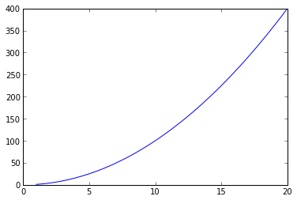

```python
%matplotlib inline
import matplotlib.pyplot as plt
plt.plot(x, y)
plt.show()
```

Given the pre-computed values for $x$ and $y$ the rule is:

$ \int_{a}^{b}f(x)dx\approx\frac{1}{2}\sum_{i=1}^{n}\left(x_{i}-x_{i-1}\right)\left(y_{i}+y_{i-1}\right). $

```python
area = 0
for i in range(1,len(x)):
    area += (x[i] - x[i-1])*(y[i] + y[i-1])
area /= 2.
print area
```

```
2666.44997109
```

Can you perform the same operations without loops?

```python
0.5 * np.dot(x[1:] - x[:-1], y[1:] + y[:-1])
```

```
2666.4499710913851
```